# PBHL-B581 Final - Introduction to plotStyle

Andrew Summers

# Motivation and Background

Effective data visualization is essential for communicating complex insights, particularly in research and professional settings. However, despite the availability of powerful tools like `ggplot2` in R, many users face persistent challenges—such as mismatched color schemes, uneven layouts, or unclear labeling—that hinder the efficiency and consistency of their visualizations. The `plotStyle` package was developed to address three key challenges commonly encountered in data visualization:

**1. Inconsistent Styling Across Visualizations**: Researchers and practitioners often struggle to maintain a consistent visual style across multiple plots. This inconsistency can detract from the clarity and professional appearance of reports, presentations, or publications. For example, using different color schemes, fonts, or plot elements across figures can confuse the viewer and reduce the overall impact of the message. While `ggplot2` and its coexisting packages have a variety of themes, they often lacks the flexibility needed for modifications to meet branding or publication-specific standards. `plotStyle` addresses this challenge by providing predefined themes and color palettes, ensuring a uniform look and feel across all plots generated within a project. Users can choose from a variety of academic, professional, or custom styles that suit their specific needs.

**2. Time-Consuming Customization of ggplot2 Plots**: While `ggplot2` offers a high degree of customization, manually tweaking every plot to achieve the desired aesthetics can be time-consuming, especially when working with multiple plots. This repetitive process often involves adjusting plot elements such as themes, axis labels, and colors, which can become tedious when applied to several figures. With `plotStyle`, users can streamline this process by using wrapper functions that automatically apply common customizations. These functions allow users to easily change plot aesthetics such as themes, axis labels, colors, and more, without needing to write extensive code for each individual plot.

**3. Limited Interactivity for Customization**: Customizing plots often requires users to modify the underlying code and trial-and-error until the desired appearance is achieved. This process can be especially daunting for those who are not familiar with the intricacies of `ggplot2` syntax or those who prefer a more hands-on approach.

To address this, `plotStyle` incorporates an interactive Shiny gadget, allowing users to visually adjust plot elements without writing code. The gadget provides a simple, intuitive interface for customizing plot features such as titles, labels, and colors, making it easy to create publication-ready figures quickly.

By tackling these challenges, `plotStyle` aims to streamline the process of generating consistent, professional-quality visualizations in R. Whether you’re preparing figures for a research paper, presentation, or report, plotStyle helps you produce aesthetically appealing plots with minimal effort.

# Package Content

The `plotStyle` package offers a set of functions that provide publication-ready, consistent styling for `ggplot2` plots. It includes customizable themes, color palettes, and specialized plotting functions that streamline the process of generating high-quality visualizations.

**Key Functions:**

**1. custom_scatter()**: Custom Scatter Plot Function

This function creates a scatter plot with consistent, publication-ready styling. Users can specify the x and y variables, choose the color of the points, and select from pre-defined themes such as “default” or “minimal”. The function also allows for a custom plot title, ensuring a tailored appearance.

```
        Parameters:
        **x**: A string specifying the column name for the x-axis.
        **y**: A string specifying the column name for the y-axis.
        **data**: A data frame containing the variables for the plot.
        **color**: A string specifying the color of the points. Default is "purple".
        **theme**: A string specifying the theme to apply. Options are "default"
        (white background) or "minimal" (minimal grid lines).
        **Default** is "default".
        **title**: A string specifying the plot title. Default is "Custom Scatter Plot".
```

**2. theme_academic()**: Academic Theme for Plots

This function returns a clean, minimal theme designed for academic publications. It removes background elements and uses light grid lines to create a polished, publication-friendly aesthetic.

**3. palette_vibrant()**: Vibrant Color Palette

The `palette_vibrant()` function provides a custom, vibrant color palette that is ideal for categorical variables in `ggplot2` plots. This palette can be applied using scale_color_manual() for categorical data or scale_color_gradient() for continuous data to add visually striking colors to plots.

**4. custom_plot_gadget()**: Shiny Application

The `custom_plot_gadget()` function launches an interactive Shiny app that allows users to create customized scatter plots. Through the gadget, users can select variables for the x- and y-axes, customize the point color, choose between different plot themes (e.g., default or minimal), and add a custom title. The app instantly updates the plot in the main panel, providing an intuitive and user-friendly interface for creating visually appealing and personalized plots. This tool is especially useful for users who want to quickly explore and customize their data visualizations without writing extensive code.

**Additional Features**

1. Customizable Plot Elements All functions within the `plotStyle` package are designed for easy customization. The `custom_scatter()` function, for example, allows users to adjust the plot title, point color, and theme without needing to manually adjust the plot’s components. This feature simplifies the creation of high-quality, consistent plots.
2. Publication-Ready Styling Each function is tailored to generate publication-quality plots, with themes and color palettes that are optimized for clarity, consistency, and professional appearance. The package removes the need for manual styling adjustments, enabling users to focus on data visualization rather than aesthetic details.
3. Flexibility Users can easily extend the package by adding their own themes, color palettes, or plot functions. The package is designed to be modular, so it can easily integrate with other R packages and workflows.

# Function Examples

**custom_scatter**

The `custom_scatter()` function allows you to easily create scatter plots with customized colors and themes. Here’s an example of how to use it:

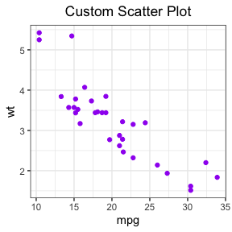

```r
# Basic Example: Default settings
library(plotStyle)
custom_scatter("mpg", "wt", mtcars)
```

This will create a scatter plot with the mpg variable on the x-axis and wt on the y-axis, using the default color (“purple”) and theme (“default”).

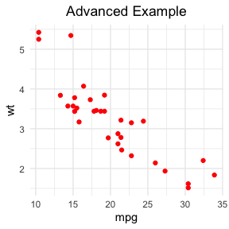

```r
# Advanced Example: Combining customizations
custom_scatter("mpg", "wt", mtcars, color = "red", title = "Advanced Example", theme = "minimal")
```

**theme_academic**

The `theme_academic()` function provides a clean, academic-style theme that is suitable for publications:

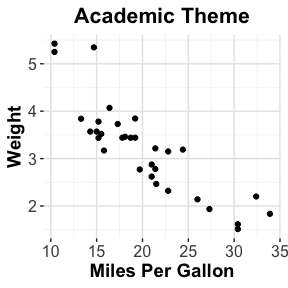

```r
ggplot(mtcars, aes(mpg, wt)) +
    geom_point() +
    theme_academic() +
    labs(title = "Academic Theme", x = "Miles Per Gallon", y = "Weight")
```

In this plot, you can see that the background is blank, the grid lines are light gray, and the axis titles are bold—ideal for academic contexts.

**palette_vibrant**

The `palette_vibrant()` function gives you a set of vibrant colors for your plots. You can use it to customize the color scheme of your plots:

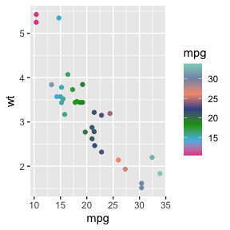

```r
ggplot(mtcars, aes(mpg, wt)) + geom_point(aes(color = mpg)) + scale_color_gradientn(colors = palette_vibrant())
```

This example applies the vibrant color gradient based on the mpg variable (continuous). It adds a dynamic, visually appealing range of colors to the scatter plot.

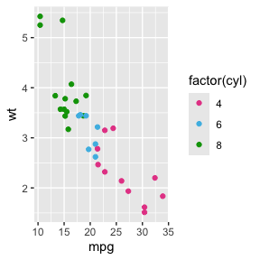

```r
ggplot(mtcars, aes(mpg, wt)) +
  geom_point(aes(color = factor(cyl))) +
  scale_color_manual(values = palette_vibrant())
```

In this case, the color of the points depends on the cyl variable (catergorical), and the palette_vibrant() colors are applied to give the plot an eyecatcing appearance.

**Combining Functions**

You can combine these functions to have even more flexibility in creation:

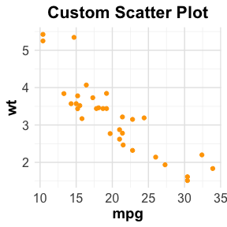

```r
custom_scatter("mpg", "wt", mtcars, color = "orange", theme = "minimal") +
    scale_color_manual(values = palette_vibrant()) +
    theme_academic()
```

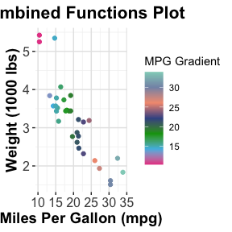

```r
ggplot(mtcars, aes(mpg, wt)) +
    geom_point(aes(color = mpg)) + #Adds scatter points with a gradient color based on the mpg variable.
    scale_color_gradientn(colors = palette_vibrant()) + #Uses the vibrant color palette to create a visually dynamic gradient.
    theme_academic() + #Applies the academic theme for a clean and publication-ready appearance.
    labs(
        title = "Combined Functions Plot",
        x = "Miles Per Gallon (mpg)",
        y = "Weight (1000 lbs)",
        color = "MPG Gradient"
    ) #Customizes the title, axis labels, and color legend for better clarity.
```

# Shiny Gadget for Interactive Plot Customization

One of the key features of `plotStyle` is the interactive Shiny gadget, `custom_plot_gadget()`, which allows you to customize plots interactively. To launch the gadget, run the following code, and enter in the dataset of your choosing:

```r
if (interactive()) custom_plot_gadget(data = mtcars) #I am using mtcars as the example dataset
```

Running this Shiny app (with the data set of your choosing) will allow you to select the x-axis and y-axis variables, choose a color for the points, pick between the “default” or “minimal” themes, and add a custom title.

*Note: If you go to the “Help” section in R and search for any of these functions (after downloading and installing), it will offer a brief synopsis of what they do and how to use them.

# Future Work

While `plotStyle` already offers several useful features, I plan to enhance the package in the future:

1. **Adding more themes**: I plan to introduce additional themes, including those tailored for posters, websites, and presentations. Any new themes will be added at the end of each update period (monthly).
2. **Improving the Shiny gadget**: Future updates to the Shiny gadget will include the ability to adjust plot size, axis labels, and text size directly within the interface, expected by August 2025.
3. **Exporting high-quality images**: I will implement export options for PNG, SVG, and PDF formats, ensuring that plots are resized and output at high resolutions. I expect this function to be created by June 2025.

# Conclusion

The `plotStyle` is designed to save time and improve the consistency of visualizations. With its customizable themes, color palettes, and interactive features, users can quickly create publication-ready plots in R. I hope that `plotStyle` enhances your data visualization experience, making it easier to communicate your insights effectively.

# Installation

To install and use `plotStyle`, please follow the steps below:

1. **Install Required Packages**: (required)
   - Install any required packages using the following command:

     ```r
     install.packages(c("devtools", "ggplot2", "shiny", "shinyWidgets", "colourpicker"))
     ```

2. **Load The Packages**: (required)
   - Load it using:

     ```r
     library(devtools)
     library(ggplot2)
     library(shiny)
     library(shinyWidgets)
     library(colourpicker)
     ```

3. **Install the package** There are two ways to install `plotStyle`:

Option 1: Install from GitHub (Recommended). If you have devtools installed, you can install plotStyle directly from GitHub with this command:

```r
devtools::install_github("andsumme/plotStyle")
```

4. **Load the package** Once the package is installed, load it into your R session:

```r
library(plotStyle)
```

**OR**

Option 2: Download ZIP from GitHub, if you’d prefer to manually download the package:

1. **Download the Repository from GitHub**:
   - Open RStudio.
   - Go to https://github.com/andsumme/plotStyle.git
   - Click on the **Code** button and select **Download ZIP**.
   - Extract the ZIP file to a directory on your computer.
2. **Open the Project in RStudio**:
   - Open RStudio.
   - Go to **File** > **Open Project**.
   - Navigate to the directory where you extracted the ZIP file.
   - Select the `.Rproj` file (if available) or the main directory of your project.
   - This will open all aspects of the project for you. Check the “Files” tab to make sure you have what you need opened.
3. **Load the `plotSyle` package**:

   ````
   ```
   load_all("path/to/your/project")
   ```
   ````

Now you’re ready to use the functions from `plotStyle` to create beautiful, publication-ready plots with `ggplot2`.